# Government spending multipliers

Ramey and Zubairy (2018), linear model: US quarterly data, 1889Q1–2015Q4

Ramey and Zubairy (2018, *JPE*) estimate how much GDP rises when government spending rises, using more than a century of US quarterly data. This page replicates the baseline linear model from their Stata program `jordagk.do`: the impulse responses, the one-step cumulative multiplier, the two-step multiplier and the weak-instrument diagnostic. The authors build every lead, cumulated sum and lag by hand and loop `ivreg2` over horizons. Here each is a single call.

## Data and specification

The cleaned dataset ships with the package as `docs/src/data/ramey_zubairy.csv`, built from the replication package with the variable definitions of `jordagk.do`. GDP and spending are divided by potential GDP (the Gordon–Krenn normalization), so regression coefficients are already in dollars of GDP per dollar of spending.

```julia
rz = rz_data()
first(rz[:, [:quarter, :y, :g, :newsy, :unemp]], 3)
```

3×5 DataFrame

| Row | quarter Float64 | y Float64 | g Float64 | newsy Float64? | unemp Float64? |
| --- | --- | --- | --- | --- | --- |
| 1 | 1889.0 | 1.09647 | 0.0559437 | missing | missing |
| 2 | 1889.25 | 1.07006 | 0.0466937 | missing | missing |
| 3 | 1889.5 | 1.05811 | 0.0538831 | missing | missing |

Two shocks identify spending changes:

| Shock | Instrument $s_t$ | Controls $w_{t-1}$ |
| --- | --- | --- |
| Military news | `newsy`: news about future military spending, over lagged potential GDP | 4 lags of `newsy`, `y`, `g` |
| Blanchard–Perotti | `bp`: current spending, taken as predetermined | 4 lags of `y`, `g` |

`newsy` starts in 1890Q1: the file begins in 1889Q1, and its first lag does not exist.

## Impulse responses

The responses of spending and GDP at horizon $h$ are the coefficients on the shock in $x_{t+h} = \alpha_h + \beta_h s_t + \gamma_h' w_{t-1} + u_{t+h}$. `leads(x)` puts $x_{t+h}$ on the left and `lp` runs the regression for every $h$ up to `horizon`:

```julia
irf_y_news = lp(@formula(leads(y) ~ newsy + lags(newsy, 4) + lags(y, 4) + lags(g, 4)),
    rz; horizon = 20)
irf_g_news = lp(@formula(leads(g) ~ newsy + lags(newsy, 4) + lags(y, 4) + lags(g, 4)),
    rz; horizon = 20)
irf_y_bp = lp(@formula(leads(y) ~ bp + lags(y, 4) + lags(g, 4)), rz; horizon = 20)
irf_g_bp = lp(@formula(leads(g) ~ bp + lags(y, 4) + lags(g, 4)), rz; horizon = 20)

hac = Bartlett{NeweyWest}()      # Newey–West, automatic bandwidth
summarize(irf_y_news, hac; term = :newsy, level = 0.90)
```

```
            Impulse response of y to newsy
╭─────────┬────────┬──────────┬───────────┬───────────╮
│ Horizon │   Coef │ Std.Err. │ Lower 90% │ Upper 90% │
├─────────┼────────┼──────────┼───────────┼───────────┤
│       0 │  0.051 │   0.0169 │    0.0232 │    0.0788 │
│       1 │ 0.0747 │   0.0334 │    0.0198 │    0.1297 │
│       2 │ 0.1069 │   0.0338 │    0.0513 │    0.1624 │
│       3 │ 0.1134 │   0.0274 │    0.0684 │    0.1584 │
│       4 │ 0.1612 │   0.0378 │    0.0991 │    0.2233 │
│       5 │ 0.1945 │   0.0454 │    0.1198 │    0.2692 │
│       6 │  0.221 │   0.0484 │    0.1413 │    0.3007 │
│       7 │ 0.2035 │   0.0512 │    0.1193 │    0.2877 │
│       8 │ 0.2295 │   0.0661 │    0.1208 │    0.3381 │
│       9 │ 0.2759 │   0.0719 │    0.1576 │    0.3941 │
│      10 │ 0.2938 │   0.0793 │    0.1633 │    0.4242 │
│      11 │ 0.2884 │   0.0852 │    0.1482 │    0.4286 │
│      12 │ 0.2563 │     0.09 │    0.1083 │    0.4044 │
│      13 │ 0.2282 │    0.099 │    0.0653 │    0.3911 │
│      14 │ 0.2084 │   0.1103 │     0.027 │    0.3897 │
│       ⋮ │      ⋮ │        ⋮ │         ⋮ │         ⋮ │
╰─────────┴────────┴──────────┴───────────┴───────────╯
                                         6 rows omitted
```

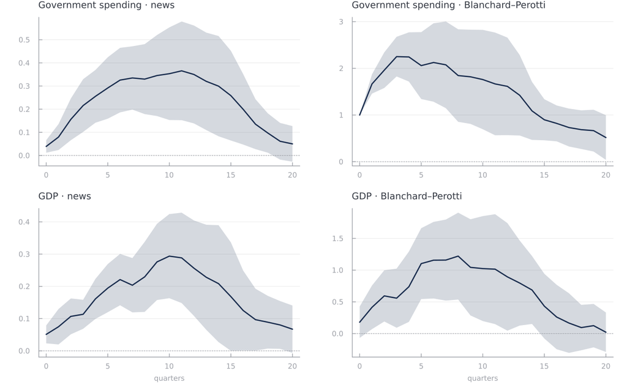

Responses of government spending and GDP. 90% bands, Newey–West automatic bandwidth.

After a news shock both responses are hump-shaped: spending peaks at 0.37 after 11 quarters, GDP at 0.29 after 10. Under Blanchard–Perotti the shock *is* current spending, so spending moves one for one on impact, keeps rising to 2.25 after 3 quarters, then declines.

## The one-step cumulative multiplier

The multiplier at horizon $h$ is cumulative extra GDP per cumulative extra dollar of spending. Ramey and Zubairy estimate it in one step, as $m_h$ in

$$\sum_{j=0}^{h} y_{t+j} = \alpha_h + m_h \sum_{j=0}^{h} g_{t+j} + \gamma_h' w_{t-1} + u_{t+h},$$

with cumulative spending instrumented by the shock $s_t$. Both sides move with the horizon, and `cumul` handles either side, so `lpiv` returns the whole multiplier path at once:

```julia
mult_news = lpiv(TSLS(), @formula(cumul(y) ~ (cumul(g) ~ newsy) +
                                  lags(newsy, 4) + lags(y, 4) + lags(g, 4)), rz; horizon = 20)
mult_bp = lpiv(TSLS(), @formula(cumul(y) ~ (cumul(g) ~ bp) + lags(y, 4) + lags(g, 4)),
    rz; horizon = 20)

s_news = summarize(mult_news, hac; level = 0.90)   # the multiplier is `shock`, no `term`
s_bp = summarize(mult_bp, hac; level = 0.90)
nobs(mult_bp)[[1, 9, 21]]                          # h = 0, 8, 20: Stata's samples
```

```
3-element Vector{Int64}:
 504
 496
 484
```

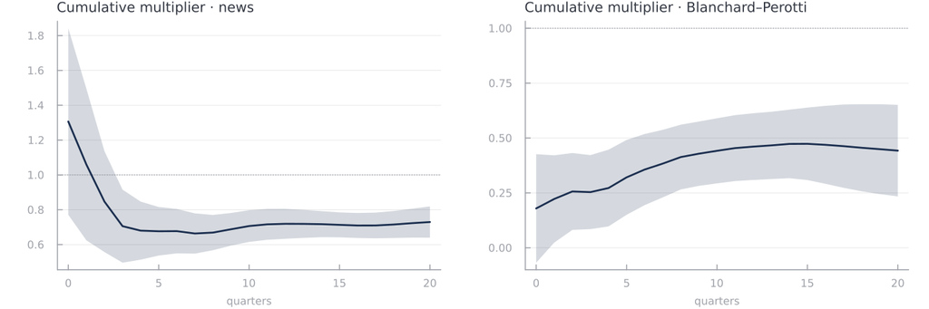

One-step cumulative multipliers. 90% bands, Newey–West automatic bandwidth; the dotted line is a multiplier of one.

The two-year multiplier is **0.67** for the news shock and **0.41** for Blanchard–Perotti. Both are below one, the paper’s headline result.

### Against the published numbers

`RZ` is the authors’ published multiplier from `Multiplier-Standard-Errors.xlsx` in the replication package. Horizons 8 and 16 are the two-year and four-year multipliers in the paper.

| h | news | s.e. | RZ | RZ s.e. | BP | s.e. | RZ | RZ s.e. |
| --- | --- | --- | --- | --- | --- | --- | --- | --- |
| 0 | 1.306 | 0.326 | 1.255 | 0.329 | 0.179 | 0.150 | 0.208 | 0.155 |
| 1 | 1.060 | 0.265 | 1.035 | 0.235 | 0.223 | 0.121 | 0.235 | 0.143 |
| 2 | 0.847 | 0.176 | 0.820 | 0.155 | 0.257 | 0.106 | 0.257 | 0.133 |
| 3 | 0.706 | 0.128 | 0.695 | 0.123 | 0.254 | 0.103 | 0.251 | 0.133 |
| 4 | 0.680 | 0.101 | 0.674 | 0.097 | 0.272 | 0.106 | 0.271 | 0.132 |
| 6 | 0.677 | 0.078 | 0.673 | 0.074 | 0.356 | 0.099 | 0.353 | 0.119 |
| 8 | 0.669 | 0.062 | 0.667 | 0.060 | 0.413 | 0.090 | 0.411 | 0.104 |
| 10 | 0.706 | 0.055 | 0.705 | 0.053 | 0.442 | 0.090 | 0.439 | 0.102 |
| 12 | 0.719 | 0.052 | 0.717 | 0.052 | 0.461 | 0.092 | 0.458 | 0.102 |
| 14 | 0.717 | 0.046 | 0.716 | 0.046 | 0.473 | 0.095 | 0.471 | 0.105 |
| 16 | 0.710 | 0.044 | 0.708 | 0.046 | 0.469 | 0.108 | 0.467 | 0.119 |
| 18 | 0.715 | 0.047 | 0.713 | 0.053 | 0.456 | 0.121 | 0.453 | 0.133 |
| 20 | 0.729 | 0.055 | 0.727 | 0.063 | 0.443 | 0.127 | 0.440 | 0.139 |

At these 13 horizons, for both shocks, every point estimate is within 0.19 published standard errors of the authors’ value, with a median gap of 0.03. The remaining difference is most likely the data vintage: the spreadsheet of published numbers predates the last revision of the shipped data by a week.

The standard errors differ more, 0.77 to 1.14 times the published ones, for two reasons:

- **Bandwidth.** The paper uses `ivreg2, robust bw(auto)`. Both sides implement the Newey–West (1994) automatic rule, but they select different bandwidths on the same regression. With a fixed bandwidth, `Bartlett(b)` here and `bw(b)` in Stata, coefficients and IV standard errors agree to about $10^{-10}$.
- **Degrees of freedom.** `ivreg2` applies no small-sample factor. The standard errors here, IV and OLS alike, carry $n/(n-k)$ and are 1–3% larger than Stata’s `ivreg2` equivalents.

## The two-step multiplier

The paper’s alternative estimator is the ratio of the cumulative sums of the two impulse responses, $\sum_{j \le h} \hat\beta^y_j \,/\, \sum_{j \le h} \hat\beta^g_j$:

```julia
twostep(ry, rg, shock) = cumsum(coefpath(ry; term = shock)) ./
                         cumsum(coefpath(rg; term = shock))
two_news = twostep(irf_y_news, irf_g_news, :newsy)
two_bp = twostep(irf_y_bp, irf_g_bp, :bp)
(news = maximum(abs.(two_news .- s_news.coef)), bp = maximum(abs.(two_bp .- s_bp.coef)))
```

```
(news = 0.0031353020818054578, bp = 0.0003613935999802753)
```

The two estimators agree to within 0.0031 (news) and 0.0004 (Blanchard–Perotti) at every horizon, because here the one-step regressions use the same sample as the impulse-response regressions. Ramey and Zubairy note that the two can diverge in other specifications, precisely when the samples differ.

## Is the instrument strong enough?

A multiplier estimated with a weak instrument is biased and its bands undercover. `weakivtest` computes the Montiel Olea–Pflueger effective *F* at each horizon, from the HAC covariance attached to the model:

```julia
w_news = weakivtest(mult_news + vcov(hac))         # one test per horizon
w_bp = weakivtest(mult_bp + vcov(hac))
w_news[9]                                          # two years out
```

```
Montiel-Pflueger robust weak instrument test
──────────────────────────────────────────────────────
TSLS coefficient (SE):          0.6690 (  0.0625)
LIML coefficient (SE):          0.6690 (  0.0625)
GMMf coefficient (SE):          0.6690 (  0.0625)
kappa:                              1.0000
F[nonrobust]:                       71.863
F[effective]:                       18.087
F[robust]:                          18.087
Confidence level alpha:               5%
──────────────────────────────────────────────────────

Use:
  Compare F[effective] or F[robust] to the common critical values below.
  If F exceeds the critical value at tau, weak-IV bias is below that tau bound.

──────────────────────────────────────────────────────
tau              Common
──────────────────────────────────────────────────────
tau=5%           37.418
tau=10%          23.109
tau=20%          15.062
tau=30%          12.045
──────────────────────────────────────────────────────
```

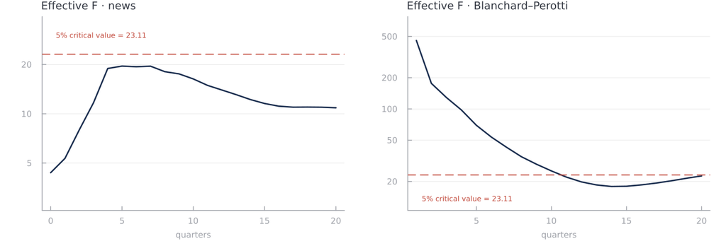

Montiel Olea–Pflueger effective F, log scale. The dashed line is the 5% critical value for a worst-case bias of 10%.

The news instrument never clears the critical value of 23.11: its effective *F* peaks at 19.57 at 5 quarters. Blanchard–Perotti is strong at short horizons and falls below the threshold from horizon 11 on. At $h = 0$ its instrument *is* the regressor: the regression treats it as exogenous, there is no first stage to test (`weakivtest` returns `nothing`), and the figure omits that point. Ramey and Zubairy respond to weak instruments with Anderson–Rubin inference, which the package does not implement yet.

## Bias correction and bootstrap bands

The bands above use Newey–West standard errors. Montiel Olea, Plagborg-Møller, Qian and Wolf (2025) recommend a different recipe for local projections: correct the estimates for small-sample bias with the procedure of Herbst and Johannsen (2024), and report either heteroskedasticity-robust standard errors or, better, the bands of a VAR moving-block bootstrap. The bootstrap fits a VAR to the data, its slopes corrected for bias with Pope’s (1990) formula, resamples its residuals in overlapping blocks, re-estimates the complete local projection on each artificial sample, and builds Hall percentile-$t$ bands. `biascorrect` and `varbootstrap` implement it, with both corrections on by default. The procedure is for OLS projections, so it covers the impulse responses but not the IV multiplier.

The VAR is fitted on the shock and the two responses, which must have no missing values, so the first quarters, before `newsy` starts, are dropped. The estimation samples do not change. The reference picks the lag order by AIC and uses it for both the projection’s controls and the bootstrap VAR:

```julia
using Random: Xoshiro
rzc = dropmissing(rz, [:newsy, :y, :g])
sel = lagselect(rzc, [:newsy, :y, :g]; maxlags = 10, criterion = :aic)
nlags(sel)
```

```
9
```

AIC picks 9 lags (BIC would pick 2). Both the four lags of the Ramey–Zubairy specification and the AIC order are shown below. `@formula` takes a literal lag count, so each order is written out:

```julia
boot(f, p) = varbootstrap(lp(f, rzc; horizon = 20), rzc; vars = [:newsy, :y, :g],
                          nlags = p, nboot = 1000, rng = Xoshiro(20260916))
# the same seed gives both responses the same artificial samples
b4 = (y = boot(@formula(leads(y) ~ newsy + lags(newsy, 4) + lags(y, 4) + lags(g, 4)), 4),
      g = boot(@formula(leads(g) ~ newsy + lags(newsy, 4) + lags(y, 4) + lags(g, 4)), 4))
b9 = (y = boot(@formula(leads(y) ~ newsy + lags(newsy, 9) + lags(y, 9) + lags(g, 9)), 9),
      g = boot(@formula(leads(g) ~ newsy + lags(newsy, 9) + lags(y, 9) + lags(g, 9)), 9))
summarize(b4.y; level = 0.90)       # bias-corrected path, Hall percentile-t band
```

```
            Impulse response of y to newsy
╭─────────┬────────┬──────────┬───────────┬───────────╮
│ Horizon │   Coef │ Std.Err. │ Lower 90% │ Upper 90% │
├─────────┼────────┼──────────┼───────────┼───────────┤
│       0 │  0.051 │   0.0146 │    0.0147 │    0.0886 │
│       1 │ 0.0752 │   0.0323 │    0.0317 │    0.1733 │
│       2 │ 0.1078 │   0.0334 │    0.0637 │    0.1839 │
│       3 │ 0.1151 │   0.0342 │    0.0695 │    0.1556 │
│       4 │ 0.1636 │   0.0477 │    0.0853 │     0.242 │
│       5 │  0.198 │   0.0554 │     0.096 │    0.3078 │
│       6 │ 0.2257 │   0.0595 │    0.1167 │    0.3423 │
│       7 │ 0.2095 │    0.066 │    0.1081 │    0.3899 │
│       8 │ 0.2365 │   0.0761 │    0.0976 │    0.4357 │
│       9 │ 0.2841 │   0.0792 │    0.1009 │    0.4399 │
│      10 │ 0.3035 │   0.0841 │     0.092 │    0.4524 │
│      11 │ 0.2997 │   0.0874 │    0.0814 │      0.47 │
│      12 │ 0.2691 │   0.0912 │    0.0535 │    0.4786 │
│      13 │ 0.2421 │   0.0993 │    0.0124 │    0.5089 │
│      14 │ 0.2231 │   0.1031 │   -0.0112 │    0.5024 │
│       ⋮ │      ⋮ │        ⋮ │         ⋮ │         ⋮ │
╰─────────┴────────┴──────────┴───────────┴───────────╯
                                         6 rows omitted
```

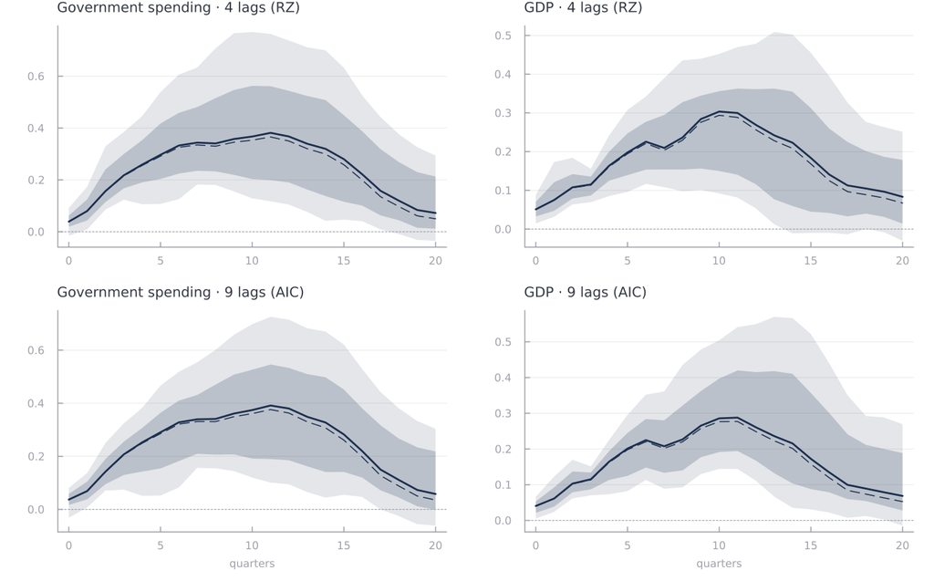

Responses to the news shock: Herbst–Johannsen bias-corrected local projection (solid) with 68% and 90% Hall percentile-t bands from the VAR moving-block bootstrap (1000 draws, Pope-corrected VAR); the uncorrected OLS path is dashed.

With four lags, GDP peaks at 0.30 after 10 quarters and spending at 0.38 after 11. On this long sample the bias correction moves the paths by at most 0.023. The 90% band excludes zero at horizons 0–13 and 18 for GDP and 1–17 for spending. With 9 lags the shape is the same (peaks of 0.29 for GDP at 11 quarters and 0.39 for spending at 11), but the bands are wider at long horizons and right-skewed: they exclude zero at horizons 0–19 for GDP and 1–16 for spending. Bands are pointwise, and because the percentile-$t$ construction corrects for bias they need not be centred on the estimate. 0 of the 4000 draws fail, and the Pope correction applies in full in all four bootstraps.